# 2_1_veri_bicimleri

Ümit Mert Çağlar

2025-02-18

## SQL

SQL veritabanlarından veri çekmek için kullanılan bir sorgulama dilidir. Bu dil sayesinde istenen kriterlere uygun, çeşitli veritabanlarından birleştirmeler gibi özelliklerle beraber veri çekilebilir. R dilinde de SQL veritabanlarından veri çekmek, veri yazmak ve kaydetmek mümkündür.

Öncelikle gerekli kütüphaneleri yükleyerek başlıyoruz.

```r
library(odbc) #Contains drivers to connect to a database
library(DBI) #Contains functions for interacting with the database
library(RSQL) #Generate and Process 'SQL' Queries in R
library(RSQLite) #Can create an in-memory SQL database
library(tidyverse) #Provides helpful functions and sample data to use in R
```

Veritabanı oluşturmak için yüklediğimiz kütüphanede var olan population ve who verisetlerini yüklüyoruz.

Ardından hafızada yer alacak geçici bir veritabanı oluşturuyoruz.

SQLite aracılığıyla veritabanı bağlantısı tanımlayıp, yerelde yüklediğimiz verisetlerini veritabanına yazıyoruz.

```r
data("population")
data("who")

#Build the placeholder (CREATE A DATABASE)
con <- dbConnect(drv = RSQLite::SQLite(),
                 dbname = ":memory:")

dbListTables(con)
```

```
## character(0)
```

```r
#Load the population table
dbWriteTable(conn = con,
             name = "population",
             value = population)

#Load the who table
dbWriteTable(conn = con,
             name = "who",
             value = who)

dbListTables(con)
```

```
## [1] "population" "who"
```

Yerelde tuttuğumuz verisetlerini siliyor ve veritabanımıza ulaşarak verileri tablo halinde görselleştiriyoruz.

```r
#remove the local data from the environment
rm(who, population)

tbl(src = con, #the source of the database connection profile
    "who") #the name of the table to preview
```

```
## # Source:   table<`who`> [?? x 60]
## # Database: sqlite 3.47.1 [:memory:]
##    country  iso2  iso3   year new_sp_m014 new_sp_m1524 new_sp_m2534 new_sp_m3544
##    <chr>    <chr> <chr> <dbl>       <dbl>        <dbl>        <dbl>        <dbl>
##  1 Afghani… AF    AFG    1980          NA           NA           NA           NA
##  2 Afghani… AF    AFG    1981          NA           NA           NA           NA
##  3 Afghani… AF    AFG    1982          NA           NA           NA           NA
##  4 Afghani… AF    AFG    1983          NA           NA           NA           NA
##  5 Afghani… AF    AFG    1984          NA           NA           NA           NA
##  6 Afghani… AF    AFG    1985          NA           NA           NA           NA
##  7 Afghani… AF    AFG    1986          NA           NA           NA           NA
##  8 Afghani… AF    AFG    1987          NA           NA           NA           NA
##  9 Afghani… AF    AFG    1988          NA           NA           NA           NA
## 10 Afghani… AF    AFG    1989          NA           NA           NA           NA
## # ℹ more rows
## # ℹ 52 more variables: new_sp_m4554 <dbl>, new_sp_m5564 <dbl>,
## #   new_sp_m65 <dbl>, new_sp_f014 <dbl>, new_sp_f1524 <dbl>,
## #   new_sp_f2534 <dbl>, new_sp_f3544 <dbl>, new_sp_f4554 <dbl>,
## #   new_sp_f5564 <dbl>, new_sp_f65 <dbl>, new_sn_m014 <dbl>,
## #   new_sn_m1524 <dbl>, new_sn_m2534 <dbl>, new_sn_m3544 <dbl>,
## #   new_sn_m4554 <dbl>, new_sn_m5564 <dbl>, new_sn_m65 <dbl>, …
```

### SQL komutuyla veri çekme

SQL komutunu doğrudan R Markdown içerisinde çalıştırmak için aşağıdaki bölüm başlığını sql, bağlantısını “con”, çıktısını da “M1_results” olarak açıkça belirtiyoruz. Bölüm içerisine hangi verileri, hangi verisetinden, nasıl birleştirerek çekmek istediğimizi belirtiyoruz.

```sql
SELECT who.country, who.year, who.new_sp_m2534, population.population
FROM who
LEFT JOIN population ON population.country = who.country AND population.year = who.year
WHERE who.country IN ('Turkey', 'Germany') AND who.year >= 2000 AND who.year <= 2010
```

Çıktıyı incelediğimizde belirttiğimiz aralıktaki değerleri elde ettiğimizi görüyoruz.

```r
head(M1_results)
```

```
##   country year new_sp_m2534 population
## 1 Germany 2000           NA   83512459
## 2 Germany 2001           89   83583461
## 3 Germany 2002           75   83685160
## 4 Germany 2003          107   83788480
## 5 Germany 2004          130   83848844
## 6 Germany 2005          113   83835978
```

### dbGetQuery komutuyla veri çekme

Benzer şekilde R dilindeki nesnelere SQL sorgusunun anahtar kelimelerini kullanarak SQL sorgusu yapabiliriz. Aynı sorguyu aşağıdaki bölümde “select”, “from”, “ljoin” ve “where” anahtar kelimeleriyle ve dbGetQuery fonksiyonuyla “M2_results” çıktısını elde ediyoruz. Çıktıyı incelediğimizde bir önceki çıktıya aynı olduğunu gözlemliyoruz.

```r
select <- "SELECT who.country, who.year, who.new_sp_m2534, population.population"
from <- "FROM who"
ljoin <- "LEFT JOIN population ON population.country = who.country AND population.year = who.year"
where <- "WHERE who.country IN ('Turkey', 'Germany') AND who.year >= 2000 AND who.year <= 2010"

query <- paste(select, from, ljoin, where)

M2_results <- DBI::dbGetQuery(conn = con,
                              statement = query)

head(M2_results)
```

```
##   country year new_sp_m2534 population
## 1 Germany 2000           NA   83512459
## 2 Germany 2001           89   83583461
## 3 Germany 2002           75   83685160
## 4 Germany 2003          107   83788480
## 5 Germany 2004          130   83848844
## 6 Germany 2005          113   83835978
```

### dplyr ile veri çekme

dplyr kütüphanesi SQL dilinden farklı olarak filtreleme, veri seçme, birleştirme fonksiyonlarını kendi içinde tanımlandığı gibi kullanmamıza olanak sağlar. Aşağıdaki bölümde dplyr ile yukarıdaki sql sorgularının aynısını yapıyoruz. Sonuç olarak elde ettiğimiz M3_results incelendiğinde aynı değerleri çektiğimiz görünmektedir.

```r
M3_results <-
  tbl(src = con, "who") %>%
  filter(country %in% c("Turkey", "Germany"),
         year >= 2000,
         year <= 2010) %>%
  dplyr::select(country, year, new_sp_m2534) %>%
  left_join(y = tbl(src = con, "population"),
            by = c("country", "year")) %>%
  collect() #this tells dplyr to execute and store the query

head(M3_results)
```

```
## # A tibble: 6 × 4
##   country  year new_sp_m2534 population
##   <chr>   <dbl>        <dbl>      <dbl>
## 1 Germany  2000           NA   83512459
## 2 Germany  2001           89   83583461
## 3 Germany  2002           75   83685160
## 4 Germany  2003          107   83788480
## 5 Germany  2004          130   83848844
## 6 Germany  2005          113   83835978
```

## Görselleştirme

```r
library(ggplot2)
```

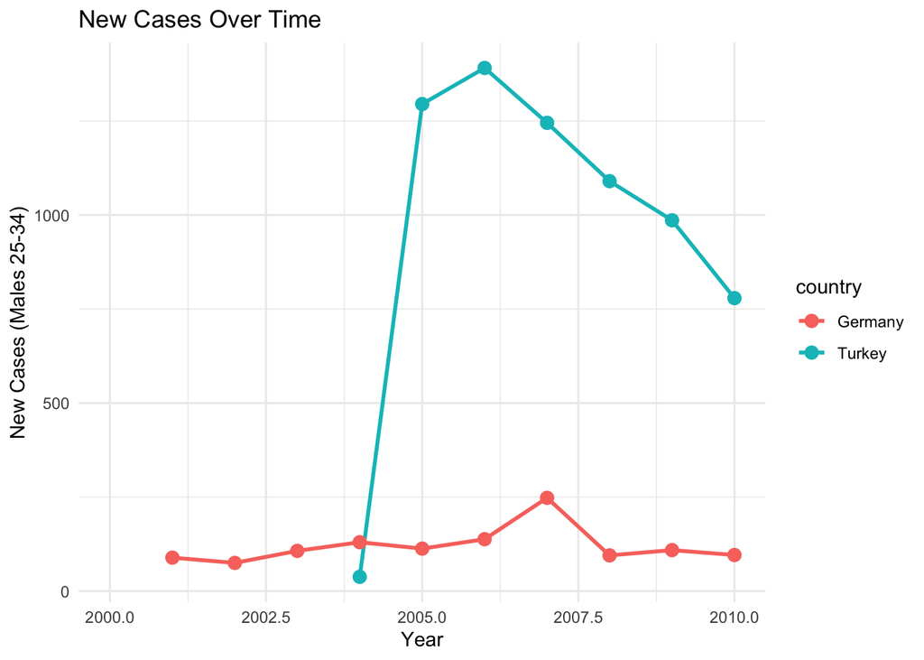

```r
data <-M1_results
ggplot(data, aes(x = year, y = new_sp_m2534, color = country, group = country)) +
  geom_line(size = 1) +
  geom_point(size = 3) +
  labs(title = "New Cases Over Time",
       x = "Year",
       y = "New Cases (Males 25-34)") +
  theme_minimal()
```

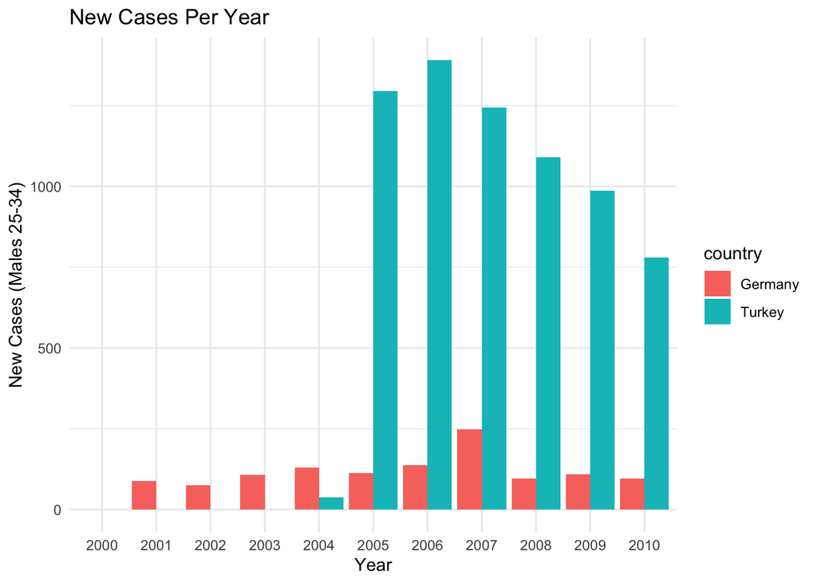

```r
ggplot(data, aes(x = as.factor(year), y = new_sp_m2534, fill = country)) +
  geom_bar(stat = "identity", position = "dodge") +
  labs(title = "New Cases Per Year",
       x = "Year",
       y = "New Cases (Males 25-34)") +
  theme_minimal()
```

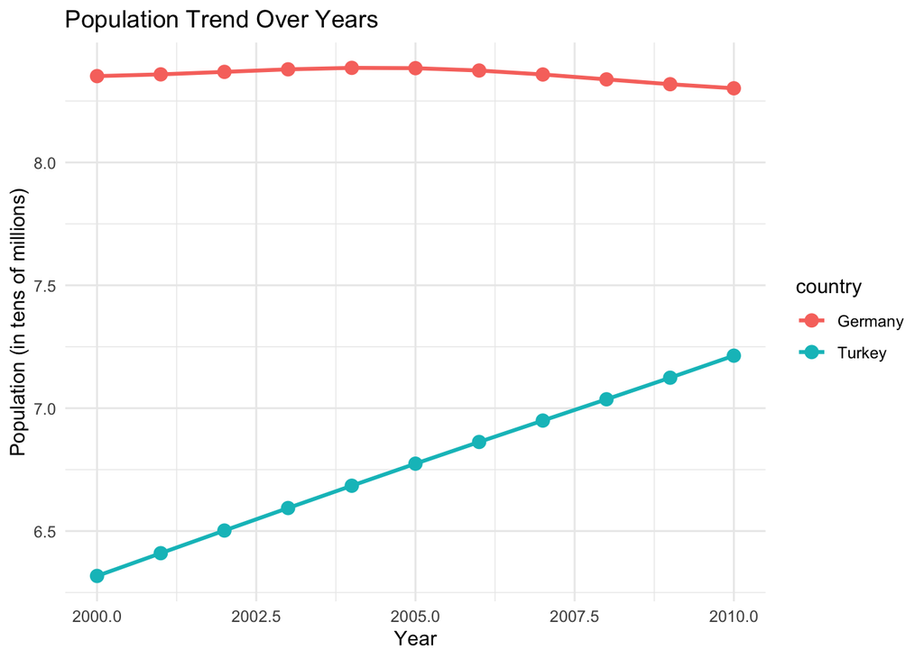

```r
ggplot(data, aes(x = year, y = population / 1e7, color = country, group = country)) +
  geom_line(size = 1) +
  geom_point(size = 3) +
  labs(title = "Population Trend Over Years",
       x = "Year",
       y = "Population (in tens of millions)") +
  theme_minimal()
```

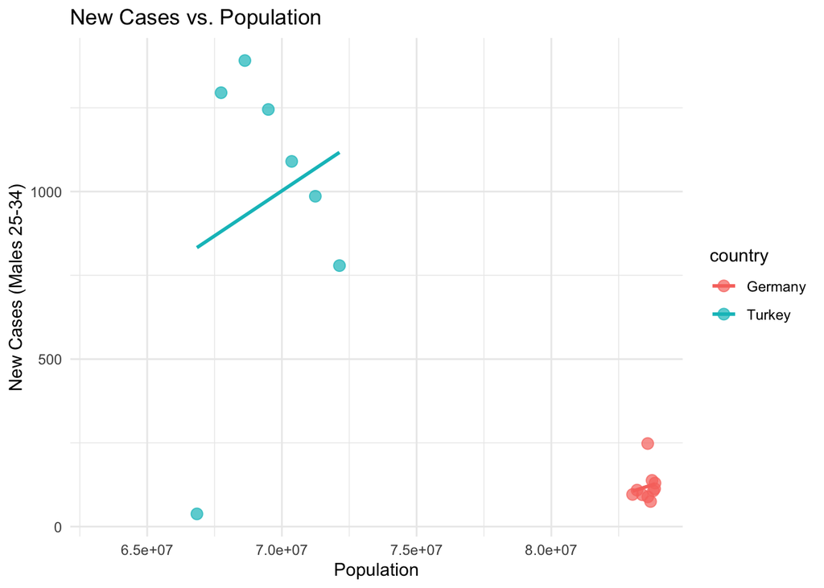

```r
ggplot(data, aes(x = population, y = new_sp_m2534, color = country)) +
  geom_point(size = 3, alpha = 0.7) +
  geom_smooth(method = "lm", se = FALSE) +
  labs(title = "New Cases vs. Population",
       x = "Population",
       y = "New Cases (Males 25-34)") +
  theme_minimal()
```